# Linear Regression Report

Jacqueline Liu

October 8, 2016

### Abstract:

Linear regression is a simple, yet powerful method of modeling and supervised learning. Many real-world phenomena can be represented as a linear model, or with other models that employ linear regression. The well-known and well-referenced text **An Introduction to Statistical Learning** covers this technique in chapter 3, section 1 *Simple Linear Regression*. Here we will reproduce their results to highlight key steps and ideas.

### Introduction:

There is a wide variety of applications for linear regression; it can be used for prediction of response to a medical treatment, forecasting prices of fruits a month from now, or determining whether or not sleep and grades are correlated. Ultimately, the goal is to describe some trend or relationship in a dataset. Once the appropriate model is found, predictions can be made for certain variables if given the values of others and the strength of relationships can be assessed. Here, we’ll be looking at a commercial setting and determining the relationship between advertising spending and sales of a given product. Specifically, we want to predict sales given the advertising budget for three different media outlets.

### Data:

The `Advertising` dataset was ‘collected’ from 200 different markets. It records the advertising budgets (in thousands of dollars) for `TV`, `Radio`, and `Newspaper` as well as the number of `Sales` (in thounds of units) for each of the markets. Because `Sales` is what we’re ultimately trying to predict, it is our response variable while the other three columns will be our features.

### Methodology:

We’re using linear models, which can be written as:
$$Y = \beta_0 + \beta_1$$
Given X and Y, the coefficients $\beta_0$ and $\beta_1$ are chosen to minimize the sum of squared errors:
$$SSE = \sum (Y - \hat{Y})^2$$
giving our regression line the name “least squares regression”. There are other loss metrics we could use (weighted errors, least absolute deviation, L1-norm penalty) but least squares is one of the most widedly used. We can regress `Sales` on `TV`, then on `Radio`, and lastly `Newspaper` to find three different linear models.

### Results:

To visualize the data and the proposed model, here are scatterplots with the calculated regression lines:

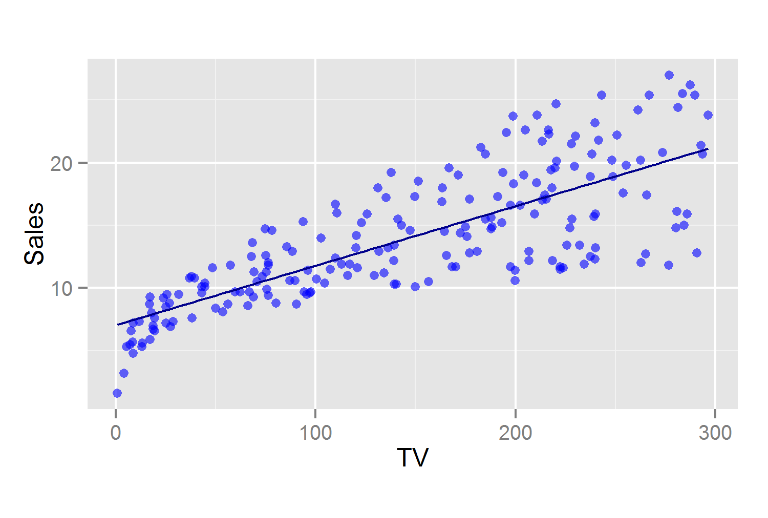

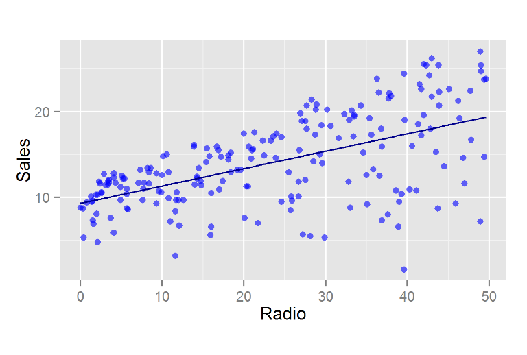

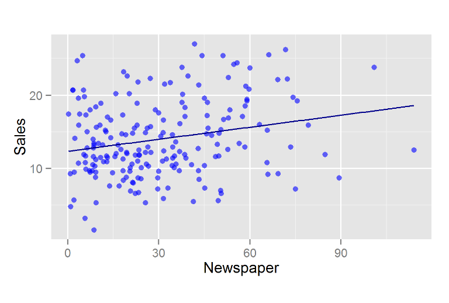